# Pràctica 2 - Neteja i validació de dades

Jordi Puig Benages

3 de enero, 2022

## 1 - Conceptes prèvis

## 1.1 - Presentació

En aquesta pràctica s’elabora un cas pràctica orientat a aprendre a identificar les dades rellevants per un projecte analític i usar les eines d’integració, neteja, validació i anàlisi de les mateixes.

## 1.2 - Competències

En aquesta pràctica es desenvolupen les següents competències del Màster de Data Science:

- Capacitat d’analitzar un problema en el nivell d’abstracció adequat a cada situació i aplicar les habilitats i coneixements adquirits per abordar-lo i resoldre’l.
- Capacitat per aplicar les tècniques específiques de tractament de dades (integració, transformació, neteja i validació) per al seu posterior anàlisi.

## 1.3 - Objectius

Els objectius concrets d’aquesta pràctica són:

- Aprendre a aplicar els coneixements adquirits i la seva capacitat de resolució de problemes en entorns nous o poc coneguts dintre de contextos més amplis o multidisciplinaris.
- Saber identificar les dades rellevants i els tractaments necessaris (integració, neteja i validació) per dur a terme un projecte analític.
- Aprendre a analitzar les dades adequadament per abordar la informació continguda en les dades.
- Identificar la millor representació dels resultats per tal d’aportar conclusions sobre el problema plantejat en el procés analític.
- Actuar amb els principis ètics i legals relacionats amb la manipulació de dades en funció de l’àmbit d’aplicació.
- Desenvolupar les habilitats d’aprenentatge que els permetin continuar estudiant d’una manera que haurà de ser en gran manera autodirigida o autònoma.
- Desenvolupar la capacitat de cerca, gestió i ús d’informació i recursos en l’àmbit de la ciència de dades.

## 2 - Resolució

## 2.1 - Descripció del dataset

En aquesta pràctica s’elabora un projecte de tractament i anàlisi de dades a partir d’un dataset generat amb la informació disponible a https://fbref.com/en/comps/

El conjunt de dades shooting_stats_big5_leagues_21_22 conté informació d’una mostra de tots els jugadors que han participat en partits oficials de les 5 lligues europees de futbol més importants: la lliga espanyola, la lliga anglesa, la lliga francesa, l’alemanya i la italiana. En el conjunt de dades es recullen mètriques relacionades amb els tirs.

Els camps que trobem al dataset són els següents:

- Rk: identificador del jugador
- Player: nom del jugador i identificador únic de la web de fbref.com
- Nation: nacionalitat del jugador, primer en minúscules amb2/3 caràcters i després normalitzat en majúscules i 3 caràcters.
- Pos: Posició del jugador, pot ser una o dues concatenades entre GK, DF, MF i FW
- Competition: competició a la que juga entre les 5 principals europees
- Squad: equip en el que juga
- Age: edat, en format anys i dies
- Born: any de naixement
- noventas: número de blocs de 90 minuts jugats, fet servir per normalitzar després algunes mètriques per 90 minuts.
- Gls: número de gols marcats
- Sh: número de tirs
- SoT: número de tirs a porteria
- SoT%: percentatge de tirs a porteria
- Sh/90: tirs per 90 minuts
- SoT/90: tirs a porteria per 90 minuts
- G/Sh: gols per tir
- G/SoT: gols per tir a porteria
- Dist: distancia total dels tirs
- FK: tirs de falta
- PK: gols de penalti
- PKatt: tirs de penalti intentats
- xG: gols esperats
- npxG: gols esperats sense tenir en compte penaltis
- npxG/Sh: gols esperats per tir sense tenir en compte penaltis
- G-xG: diferència entre gols i gols esperats
- np:G-xG: diferència entre gols i gols esperats sense tenir en compte penaltis

## 2.2 - Integració i selecció de les dades d’interès a analitzar

- Es llegeix el fitxer shooting_stats_big5_leagues_21_22 i es guarden les dades a l’objecte shooting.
- Es verifica que les dades s’han carregat correctament.
- S’avalua que no hi hagi jugadors duplicats, en cas que fos així s’escolliria el registre amb més dades.
- Es fa un preprocessament d’alguns camps, eliminant de Player el codi a partir del caràcter ’',
- S’agafa només els 3 últims caràcters de la nacionalitat.
- Respecte la posició, es genera un camp amb posició principal, amb els dos primers caràcters del camp Pos, i posició alternativa amb els altres caracters si existeixen.
- En quant a l’edat, s’agafa només els anys, descartant els dies (que són els caràcters a partir del guió ‘-’)
- Un cop realitzats els canvis, l’objectiu és analitzar si hi ha alguna diferència important entre les grans competicions europees en termes de finalització. En una temporada en la que es parla molt de la baixada de nivell de la competició espanyola, es poden demostrar aquestes impressions amb dades? És cert que la Premier League té els millors davanters del mon?

```r
shooting <- read_excel("shooting_stats_big5_leagues_21_22.xlsx") ##Lectura de l'arxiu Excel
head (shooting, 10) ##Es mostren els primers 10 registres de l'arxiu d'entrada
```

```
## # A tibble: 10 x 26
##       Rk Player  Nation Pos   Competition Squad Age    Born noventas   Gls    Sh
##    <dbl> <chr>   <chr>  <chr> <chr>       <chr> <chr> <dbl> <chr>    <dbl> <dbl>
##  1    77 "Aaron~ ie IRL FW    Premier Le~ Brig~ 21-3~  2000 1.7          0     2
##  2    83 "Aaron~ eng E~ DF    Premier Le~ West~ 32-0~  1989 12.7         1     9
##  3   623 "Aarón~ es ESP GK    La Liga     Gran~ 26-0~  1995 3.2          0     0
##  4  1658 "Aaron~ sct S~ DF    Serie A     Bolo~ 19-2~  2002 16.1         4    15
##  5   238 "Aaron~ eng E~ MFFW  Premier Le~ Burn~ 34-2~  1987 2.1          1     4
##  6  1263 "Aarón~ es ESP DF    Bundesliga  Main~ 24-2~  1997 11.5         0    11
##  7   345 "Aaron~ eng E~ GK    Premier Le~ Arse~ 23-2~  1998 17.0         0     0
##  8  1829 "Aaron~ wls W~ MF    Serie A     Juve~ 31-0~  1990 1.1          0     0
##  9   456 "Aaron~ eng E~ DF    Premier Le~ Manc~ 24-0~  1997 14.0         0     2
## 10  2215 "Abdel~ dz ALG DF    Ligue 1     Bord~ 24-1~  1997 3.0          0     2
## # ... with 15 more variables: SoT <dbl>, SoT% <chr>, Sh_noventa <chr>,
## #   SoT_noventa <chr>, G_Sh <chr>, G_SoT <chr>, Dist <chr>, FK <dbl>, PK <dbl>,
## #   PKatt <dbl>, xG <chr>, npxG <chr>, npxG_Sh <chr>, G_xG <chr>, npG-xG <chr>
```

```r
tail(shooting, 10) ##Es mostren els darrers 10 registres de l'arxiu d'entrada
```

```
## # A tibble: 10 x 26
##       Rk Player  Nation Pos   Competition Squad Age    Born noventas   Gls    Sh
##    <dbl> <chr>   <chr>  <chr> <chr>       <chr> <chr> <dbl> <chr>    <dbl> <dbl>
##  1  2473 "Yusuf~ tr TUR MFFW  Ligue 1     Lille 24-3~  1997 5.7          1    10
##  2  2341 "Yvan ~ cm CMR MF    Ligue 1     Sain~ 24-3~  1997 9.9          0     6
##  3  2279 "Yvann~ fr FRA DF    Ligue 1     Sain~ 23-0~  1998 10.4         0     6
##  4    46 "Yves ~ ml MLI MF    Premier Le~ Brig~ 25-1~  1996 12.4         0    11
##  5   412 "Zack ~ us USA GK    Premier Le~ Manc~ 26-2~  1995 1.0          0     0
##  6  2475 "Zaydo~ fr FRA MF    Ligue 1     Sain~ 22-1~  1999 9.3          0    14
##  7  2063 "Zeki ~ tr TUR DF    Ligue 1     Lille 24-3~  1997 13.7         0    11
##  8  1388 "Zidan~ dk DEN FWMF  Bundesliga  Leve~ 16-3~  2005 0.1          0     0
##  9  1925 "Zinho~ be BEL DF    Serie A     Genoa 22-1~  1999 6.0          0     4
## 10  1664 "Zlata~ se SWE FW    Serie A     Milan 40-0~  1981 7.8          7    35
## # ... with 15 more variables: SoT <dbl>, SoT% <chr>, Sh_noventa <chr>,
## #   SoT_noventa <chr>, G_Sh <chr>, G_SoT <chr>, Dist <chr>, FK <dbl>, PK <dbl>,
## #   PKatt <dbl>, xG <chr>, npxG <chr>, npxG_Sh <chr>, G_xG <chr>, npG-xG <chr>
```

```r
summary(shooting) ##S'extreu un primer anàlisi estadístic amb les característiques bàsiques del dataset
```

```
##        Rk            Player             Nation              Pos
##  Min.   :   1.0   Length:2436        Length:2436        Length:2436
##  1st Qu.: 614.8   Class :character   Class :character   Class :character
##  Median :1238.5   Mode  :character   Mode  :character   Mode  :character
##  Mean   :1237.7
##  3rd Qu.:1855.2
##  Max.   :2478.0
##
##  Competition           Squad               Age                 Born
##  Length:2436        Length:2436        Length:2436        Min.   :1981
##  Class :character   Class :character   Class :character   1st Qu.:1992
##  Mode  :character   Mode  :character   Mode  :character   Median :1995
##                                                           Mean   :1995
##                                                           3rd Qu.:1998
##                                                           Max.   :2005
##
##    noventas              Gls               Sh              SoT
##  Length:2436        Min.   : 0.000   Min.   : 0.000   Min.   : 0.000
##  Class :character   1st Qu.: 0.000   1st Qu.: 1.000   1st Qu.: 0.000
##  Mode  :character   Median : 0.000   Median : 6.000   Median : 1.000
##                     Mean   : 1.013   Mean   : 9.126   Mean   : 2.979
##                     3rd Qu.: 1.000   3rd Qu.:13.000   3rd Qu.: 4.000
##                     Max.   :19.000   Max.   :75.000   Max.   :37.000
##
##      SoT%            Sh_noventa        SoT_noventa            G_Sh
##  Length:2436        Length:2436        Length:2436        Length:2436
##  Class :character   Class :character   Class :character   Class :character
##  Mode  :character   Mode  :character   Mode  :character   Mode  :character
##
##
##
##
##     G_SoT               Dist                 FK                PK
##  Length:2436        Length:2436        Min.   : 0.0000   Min.   :0.00000
##  Class :character   Class :character   1st Qu.: 0.0000   1st Qu.:0.00000
##  Mode  :character   Mode  :character   Median : 0.0000   Median :0.00000
##                                        Mean   : 0.3248   Mean   :0.09606
##                                        3rd Qu.: 0.0000   3rd Qu.:0.00000
##                                        Max.   :16.0000   Max.   :6.00000
##                                        NA's   :1
##      PKatt             xG                npxG             npxG_Sh
##  Min.   :0.0000   Length:2436        Length:2436        Length:2436
##  1st Qu.:0.0000   Class :character   Class :character   Class :character
##  Median :0.0000   Mode  :character   Mode  :character   Mode  :character
##  Mean   :0.1154
##  3rd Qu.:0.0000
##  Max.   :7.0000
##
##      G_xG              npG-xG
##  Length:2436        Length:2436
##  Class :character   Class :character
##  Mode  :character   Mode  :character
##
##
##
##
```

```r
#S'analitza els casos duplicats del camp Rk i es comprova que siguin 0
idx <- table(shooting$Rk)>1
count <- sum(idx)

#S'analitza els casos duplicats del camp Player i es comprova que siguin 0
noms_duplicats <- table(shooting$Player)>1
count2 <- sum(noms_duplicats)

#Es modifiquen alguns camps, extreient el codi del nom del player, eliminant els dies del camp edat, agafant el camp nacionalitat amb només 3 caràcters en majúsucles, i afegint la posició principal i la secundària del camp pos.
shooting$Player <- str_sub(shooting$Player,1,nchar(shooting$Player)-9)
shooting$Age <- sapply(strsplit(as.character(shooting$Age),"-"), "[",1)
shooting$Nation <- sapply(strsplit(as.character(shooting$Nation)," "), "[",2)
shooting$Pos_main <- substr(shooting$Pos,1,2)
shooting$Pos_secondary <- substring(shooting$Pos, 3)

#Es mostren els primers 10 registres del dataset modificat
head(shooting,10)
```

```
## # A tibble: 10 x 28
##       Rk Player  Nation Pos   Competition Squad Age    Born noventas   Gls    Sh
##    <dbl> <chr>   <chr>  <chr> <chr>       <chr> <chr> <dbl> <chr>    <dbl> <dbl>
##  1    77 Aaron ~ IRL    FW    Premier Le~ Brig~ 21     2000 1.7          0     2
##  2    83 Aaron ~ ENG    DF    Premier Le~ West~ 32     1989 12.7         1     9
##  3   623 Aarón ~ ESP    GK    La Liga     Gran~ 26     1995 3.2          0     0
##  4  1658 Aaron ~ SCO    DF    Serie A     Bolo~ 19     2002 16.1         4    15
##  5   238 Aaron ~ ENG    MFFW  Premier Le~ Burn~ 34     1987 2.1          1     4
##  6  1263 Aarón ~ ESP    DF    Bundesliga  Main~ 24     1997 11.5         0    11
##  7   345 Aaron ~ ENG    GK    Premier Le~ Arse~ 23     1998 17.0         0     0
##  8  1829 Aaron ~ WAL    MF    Serie A     Juve~ 31     1990 1.1          0     0
##  9   456 Aaron ~ ENG    DF    Premier Le~ Manc~ 24     1997 14.0         0     2
## 10  2215 Abdel ~ ALG    DF    Ligue 1     Bord~ 24     1997 3.0          0     2
## # ... with 17 more variables: SoT <dbl>, SoT% <chr>, Sh_noventa <chr>,
## #   SoT_noventa <chr>, G_Sh <chr>, G_SoT <chr>, Dist <chr>, FK <dbl>, PK <dbl>,
## #   PKatt <dbl>, xG <chr>, npxG <chr>, npxG_Sh <chr>, G_xG <chr>, npG-xG <chr>,
## #   Pos_main <chr>, Pos_secondary <chr>
```

## 2.3 - Neteja de les dades

En aquest apartat s’analitzen els camps per comprovar com tractar els valors buits i/o nuls, que en aquest cas, en ser en camps que són conseqüència dels tirs, que són 0 en tots els casos, es decideix per omplir amb valors 0.

Seguidament s’analitza el tipus de dades dels camps, passant a numèric alguns dels camps que quedaven com a character de forma errònia (age i xG).

Per últim, es comprova que el rang de tots els valors dels camps està dins de l’acceptable i que no hi ha valors extrems que no siguin vàlids.

L’únic matís que es durà a terme més endavant serà filtrar aquells jugadors que no han arribat a 540 minuts (noventas >=6) en el transcurs de la temporada, doncs no seria del tot fiable tenir en compte tots els registres tot i que no hagin participat un mínim de partits.

```r
rk_na <- sum(is.na(shooting$Rk)) ##No hi ha buits ni nuls
player_na <- sum(is.na(shooting$Player)) ##No hi ha buits ni nuls
nation_na <- sum(is.na(shooting$Nation)) ##No hi ha buits ni nuls
pos_main_na <- sum(is.na(shooting$Pos_main)) ##No hi ha buits ni nuls
pos_sec_na <- sum(is.na(shooting$Pos_secondary)) ##No hi ha buits ni nuls
comp_na <- sum(is.na(shooting$Competition)) ##No hi ha buits ni nuls
squad_na <- sum(is.na(shooting$Squad)) ##No hi ha buits ni nuls
age_na <- sum(is.na(shooting$Age)) ##No hi ha buits ni nuls
born_na <- sum(is.na(shooting$Born)) ##No hi ha buits ni nuls
goals_na <- sum(is.na(shooting$Gls)) ##No hi ha buits ni nuls
sh_na <- sum(is.na(shooting$Sh)) ##No hi ha buits ni nuls
sot_na <- sum(is.na(shooting$SoT)) ##No hi ha buits ni nuls
dist_na <- sum(is.na(shooting$Dist)) ## Hi ha 453 registres buits, es decideix substituir a 0 ja que són registres on tir =0
shooting$Dist [is.na(shooting$Dist)] <- 0

fk_na <- sum(is.na(shooting$FK)) ##1 registre buit, es passa a 0 doncs no té registres de tirs.
shooting$FK [is.na(shooting$FK)] <- 0

pk_na <- sum(is.na(shooting$PK))
pkatt_na <- sum(is.na(shooting$PKatt))

xg_na <- sum(is.na(shooting$xG)) ##1 registre buit, es passa a 0 doncs no té registres de tirs.
shooting$xG [is.na(shooting$xG)] <- 0

#Comprovació del data type d'alguns camps

class(shooting$Gls)
```

```
## [1] "numeric"
```

```r
class(shooting$Sh)
```

```
## [1] "numeric"
```

```r
class(shooting$SoT)
```

```
## [1] "numeric"
```

```r
class(shooting$Dist)
```

```
## [1] "character"
```

```r
shooting$Dist <- as.numeric(shooting$Dist)

class(shooting$Age)
```

```
## [1] "character"
```

```r
shooting$Age <- as.numeric(shooting$Age)
class(shooting$Age)
```

```
## [1] "numeric"
```

```r
class(shooting$xG)
```

```
## [1] "character"
```

```r
shooting$xG <- as.numeric(shooting$xG)
class(shooting$npxG_Sh)
```

```
## [1] "character"
```

```r
shooting$npxG_Sh <- as.numeric(shooting$npxG_Sh)
class(shooting$G_Sh)
```

```
## [1] "character"
```

```r
shooting$G_Sh <- as.numeric(shooting$G_Sh)

class(shooting$noventas)
```

```
## [1] "character"
```

```r
shooting$noventas <- as.numeric(shooting$noventas)

class(shooting$G_xG)
```

```
## [1] "character"
```

```r
shooting$G_xG <- as.numeric(shooting$G_xG)

class(shooting$npxG)
```

```
## [1] "character"
```

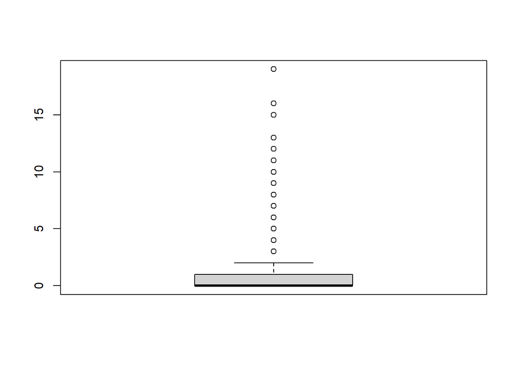

```r
shooting$npxG <- as.numeric(shooting$npxG)

write.csv(shooting, "shooting_clean.csv", row.names=FALSE)


#Valors atípics amb boxplot: si no s'aplica cap segmentació és impossible analitzar els resultat, doncs lògicament els porters o els defenses hauran realitzat molts menys tirs que els davanters.

boxplot(shooting$Gls)
```

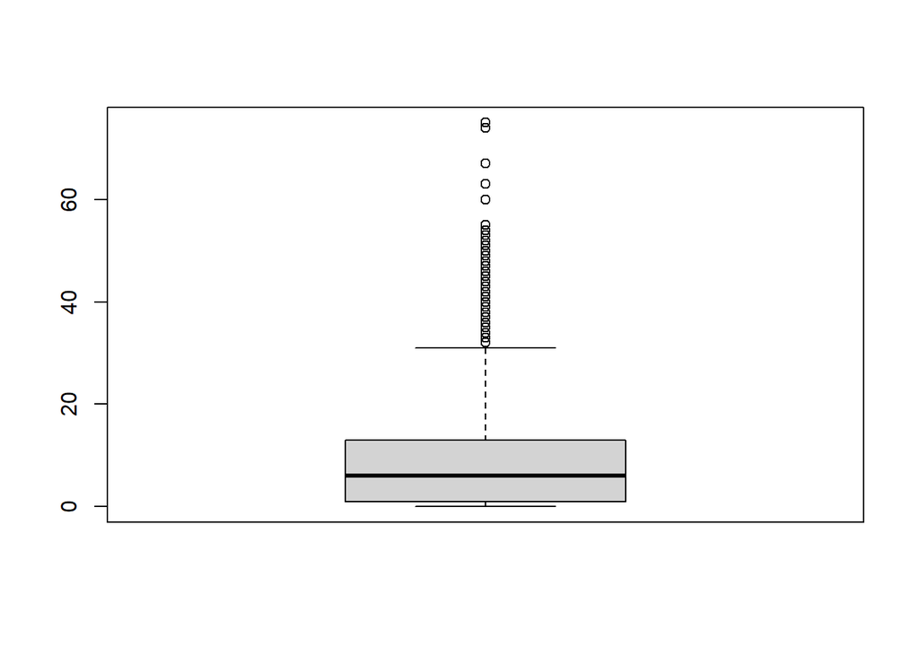

```r
boxplot(shooting$Sh)
```

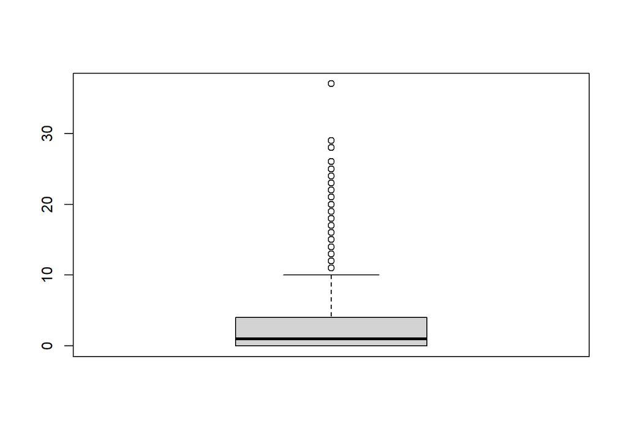

```r
boxplot(shooting$SoT)
```

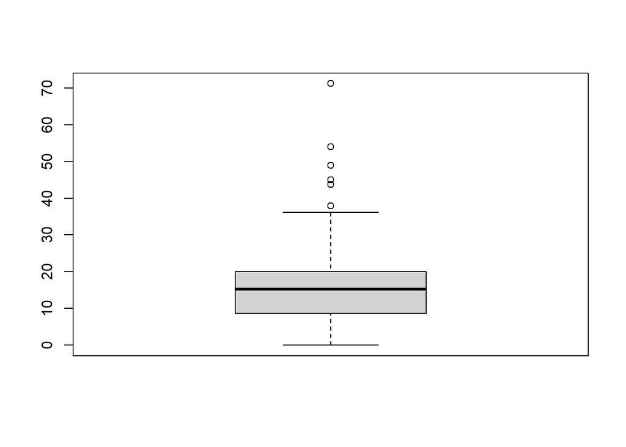

```r
boxplot(shooting$Dist)
```

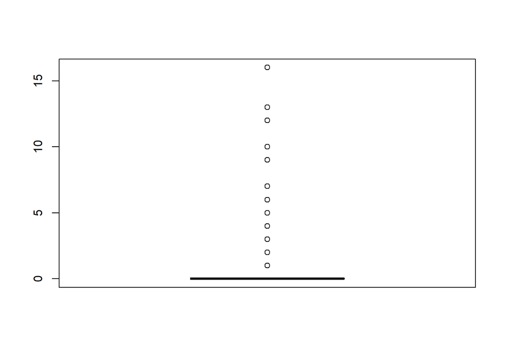

```r
boxplot(shooting$FK)
```

```r
boxplot(shooting$PK)
```

[output not shown]

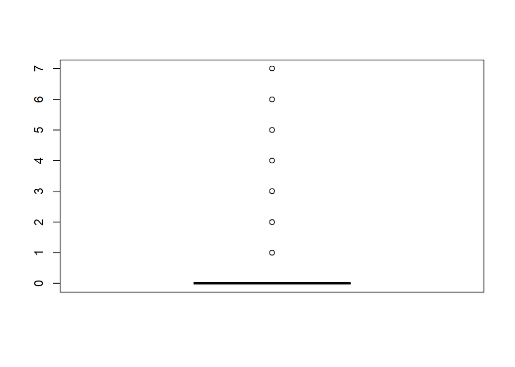

```r
boxplot(shooting$PKatt)
```

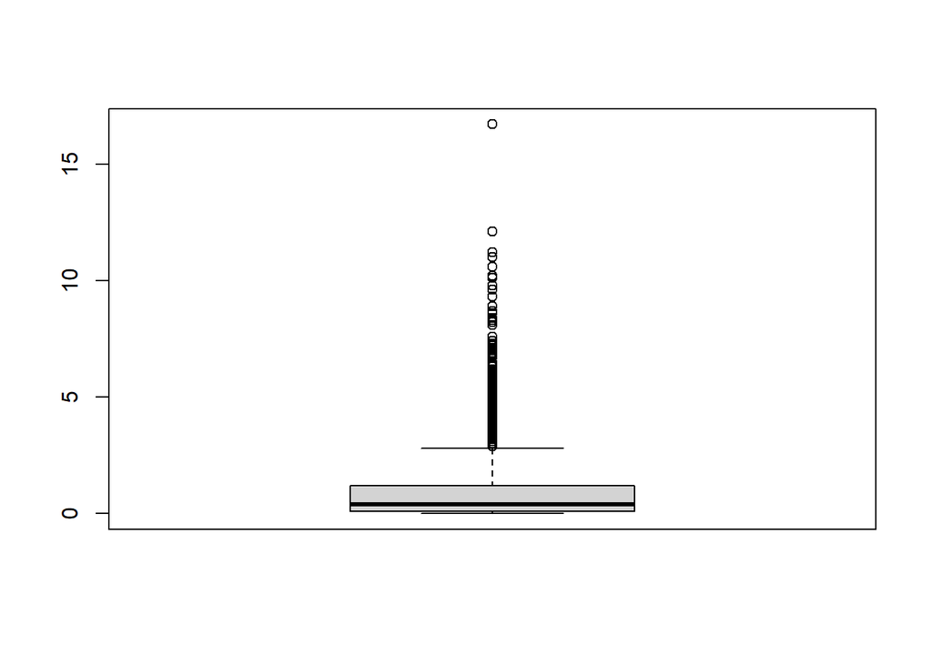

```r
boxplot(shooting$xG)
```

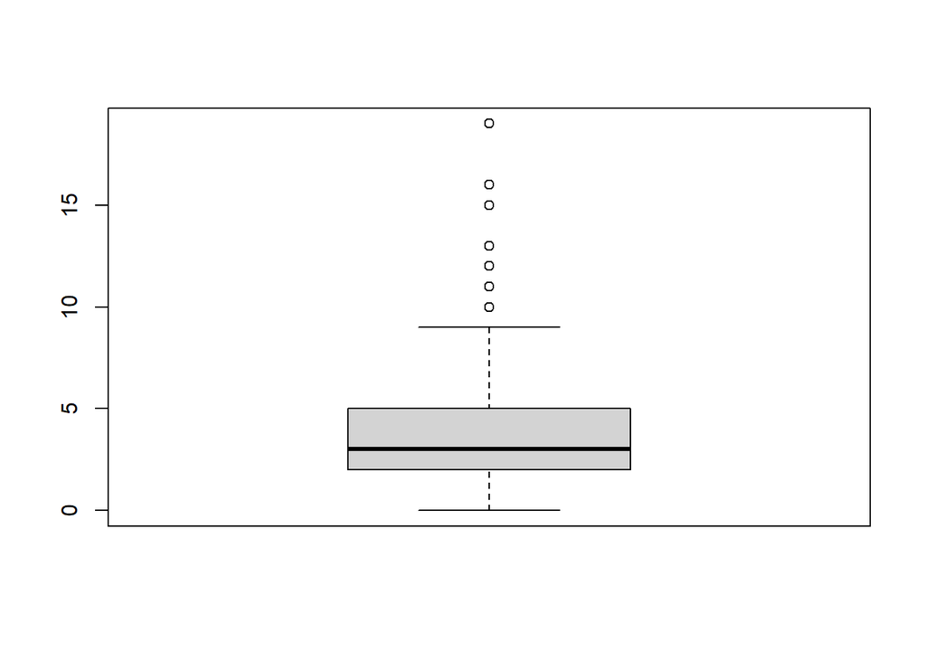

```r
#Es generen filtres per posició principal i s'analitzen els resultats. Tot i les diferències, no hi ha cap valor que s'estimi com a invàlid, doncs està dins del rang normal.

#Analitzant els davanters, que tenen els valors més alts de tirs i gols.

fwd <- filter(shooting, shooting$Pos_main=='FW' & shooting$noventas >=6)
boxplot(fwd$Gls)
```

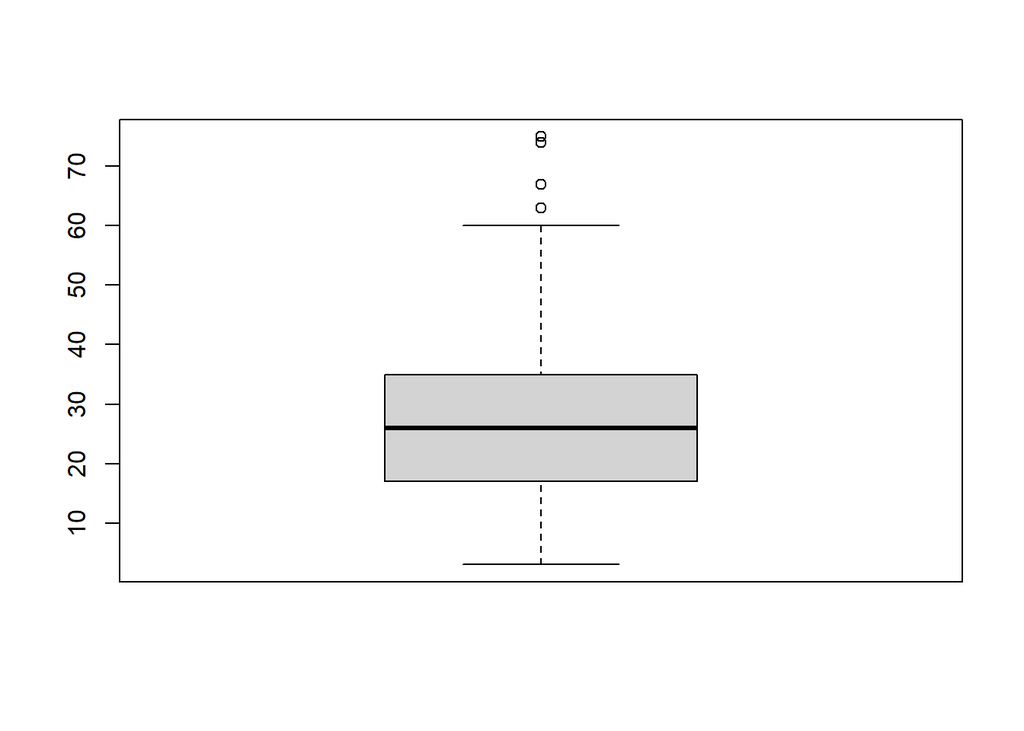

```r
boxplot(fwd$Sh)
```

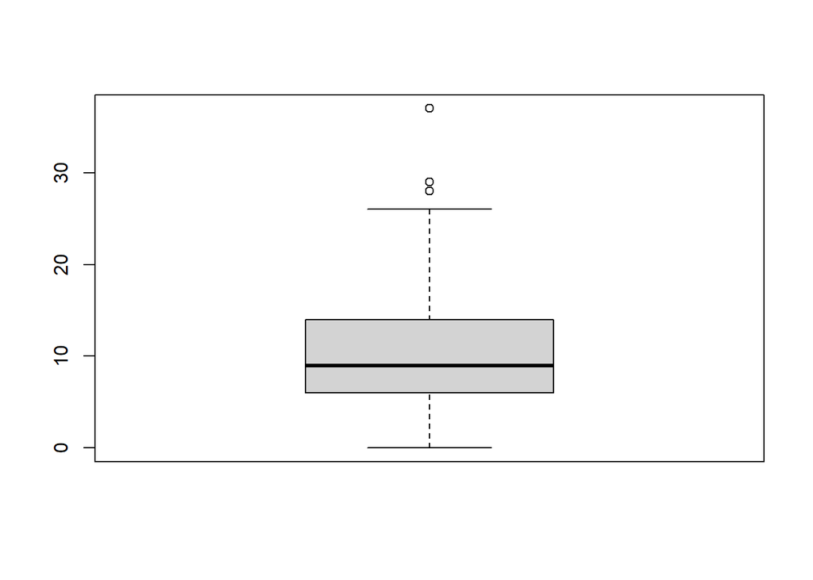

```r
boxplot(fwd$SoT)
```

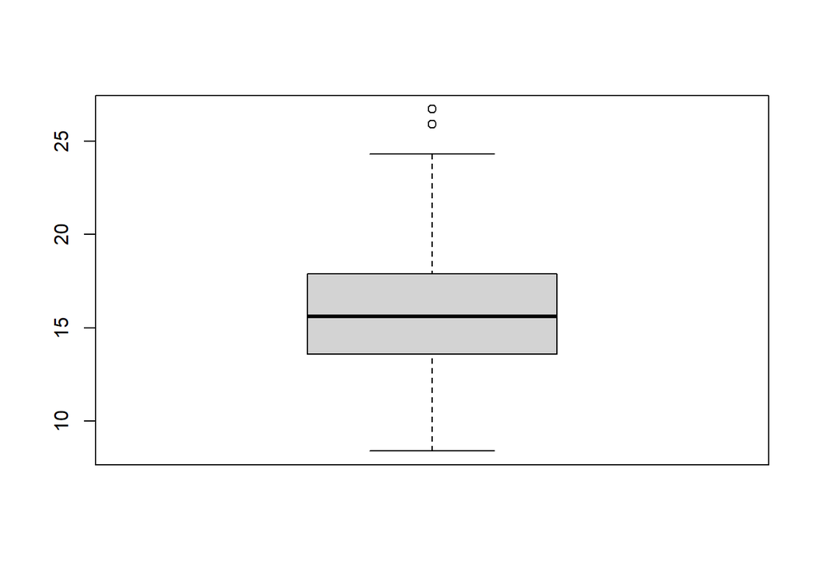

```r
boxplot(fwd$Dist)
```

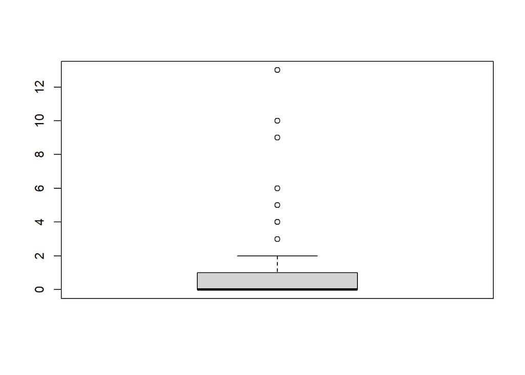

```r
boxplot(fwd$FK)
```

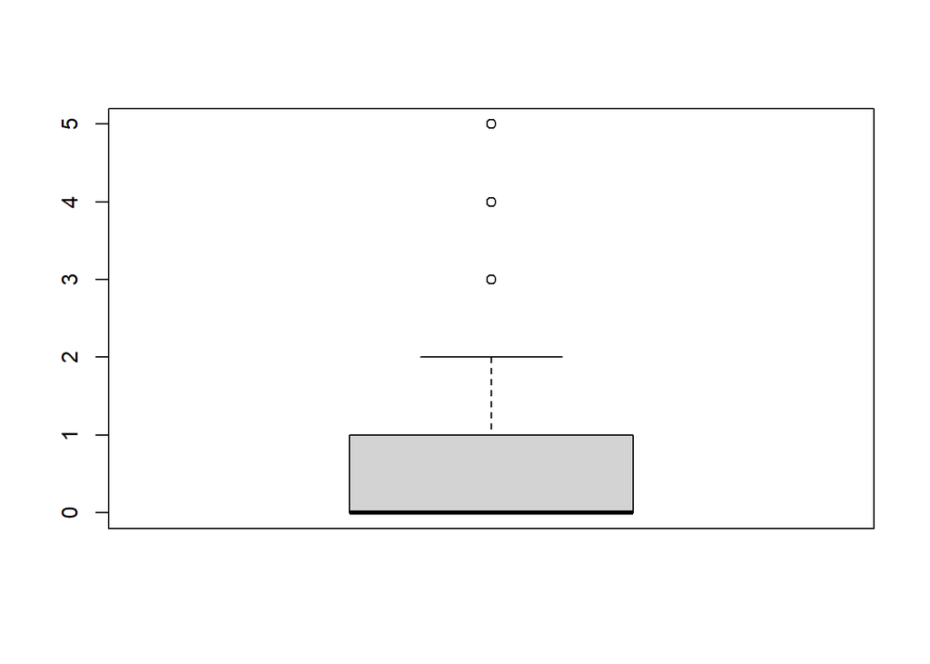

```r
boxplot(fwd$PK)
```

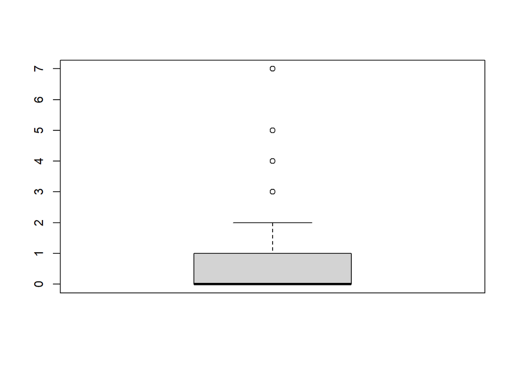

```r
boxplot(fwd$PKatt)
```

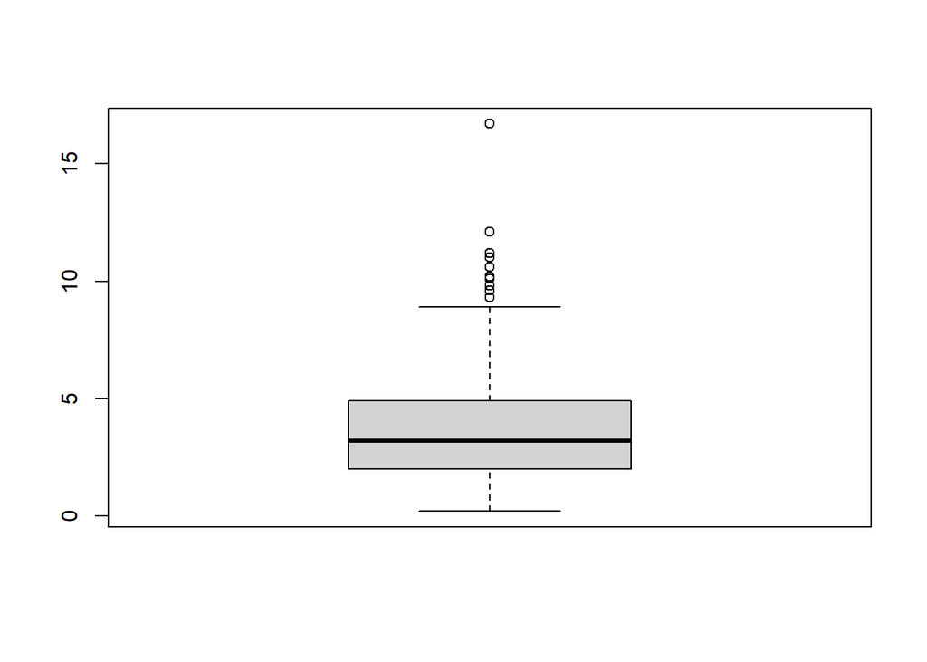

```r
boxplot(fwd$xG)
```

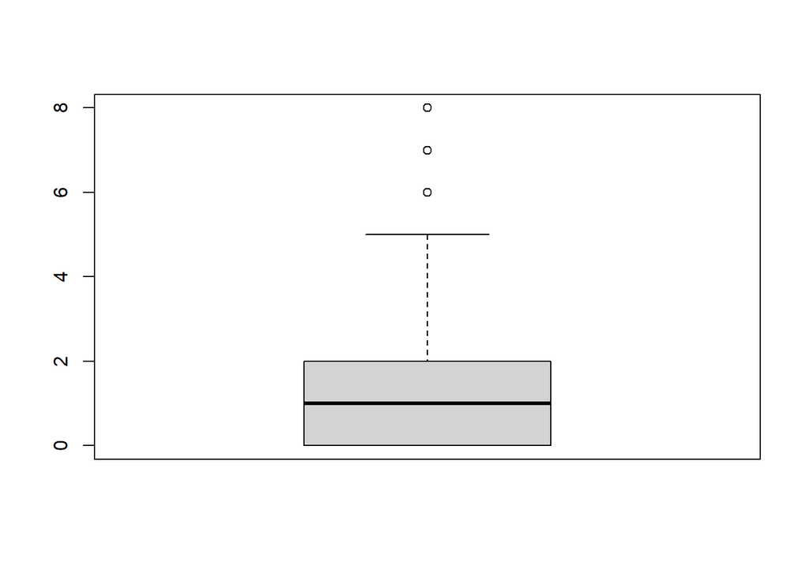

```r
#Analitzant els centrecampistes

mf <- filter(shooting, shooting$Pos_main=='MF' & shooting$noventas >=6)
boxplot(mf$Gls)
```

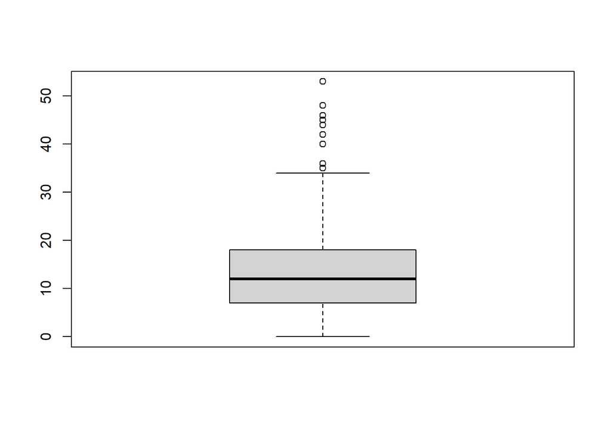

```r
boxplot(mf$Sh)
```

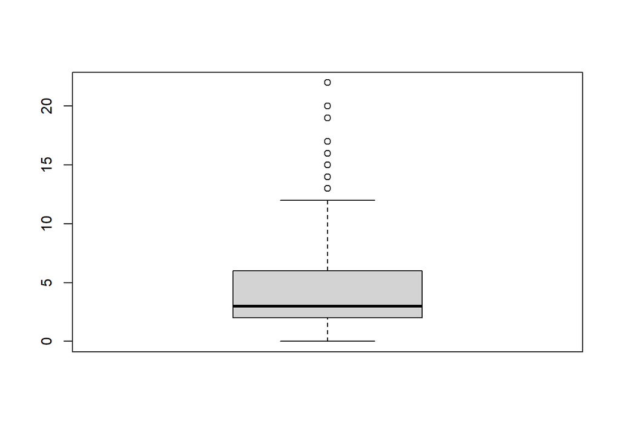

```r
boxplot(mf$SoT)
```

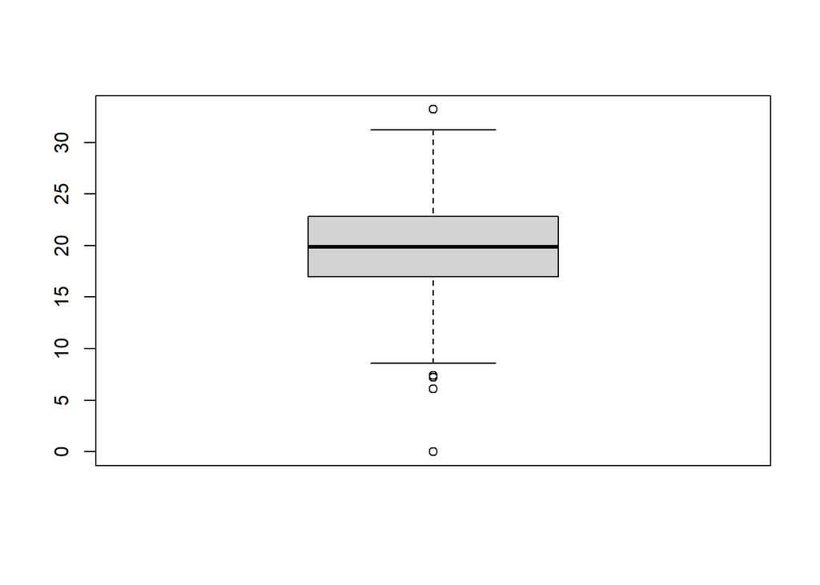

```r
boxplot(mf$Dist)
```

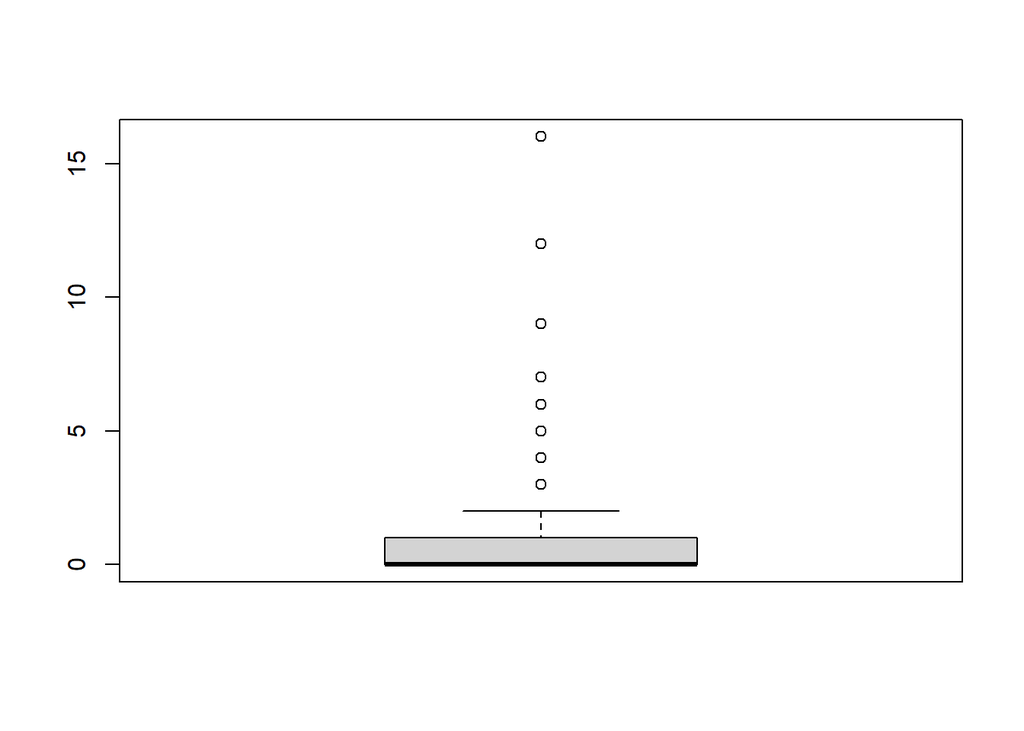

```r
boxplot(mf$FK)
```

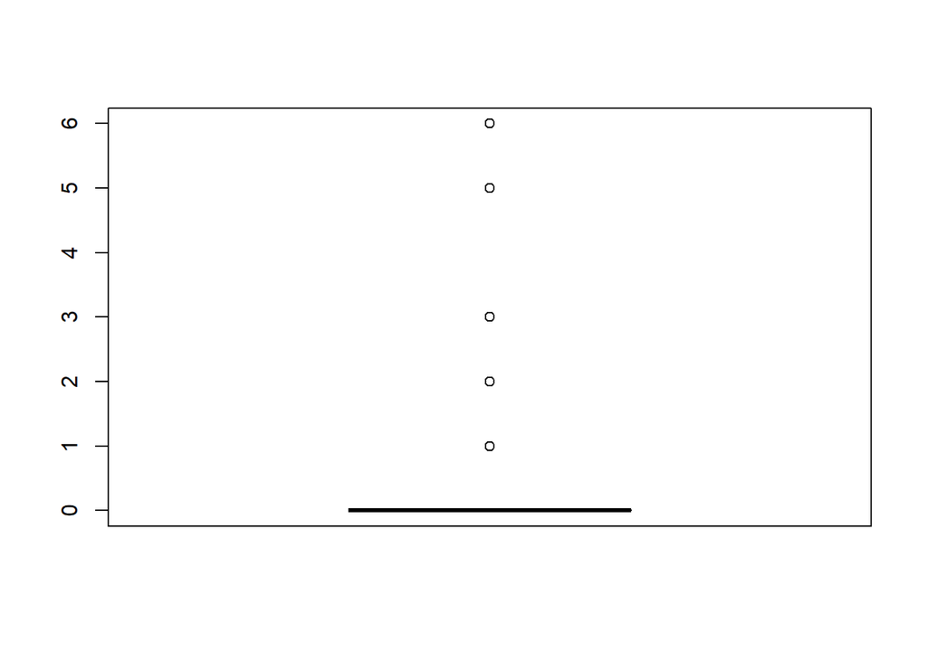

```r
boxplot(mf$PK)
```

```r
boxplot(mf$PKatt)
```

[output not shown]

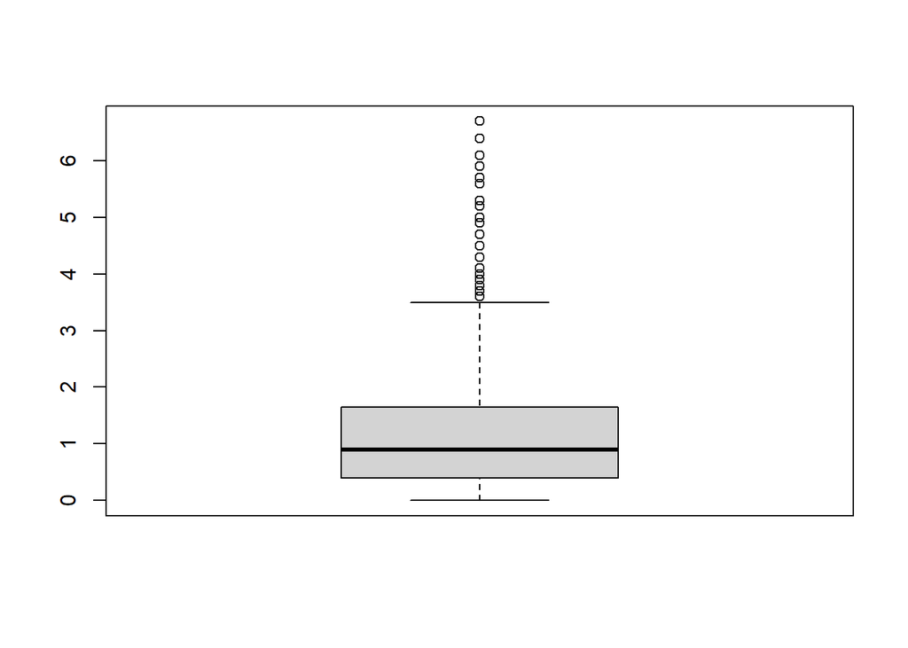

```r
boxplot(mf$xG)
```

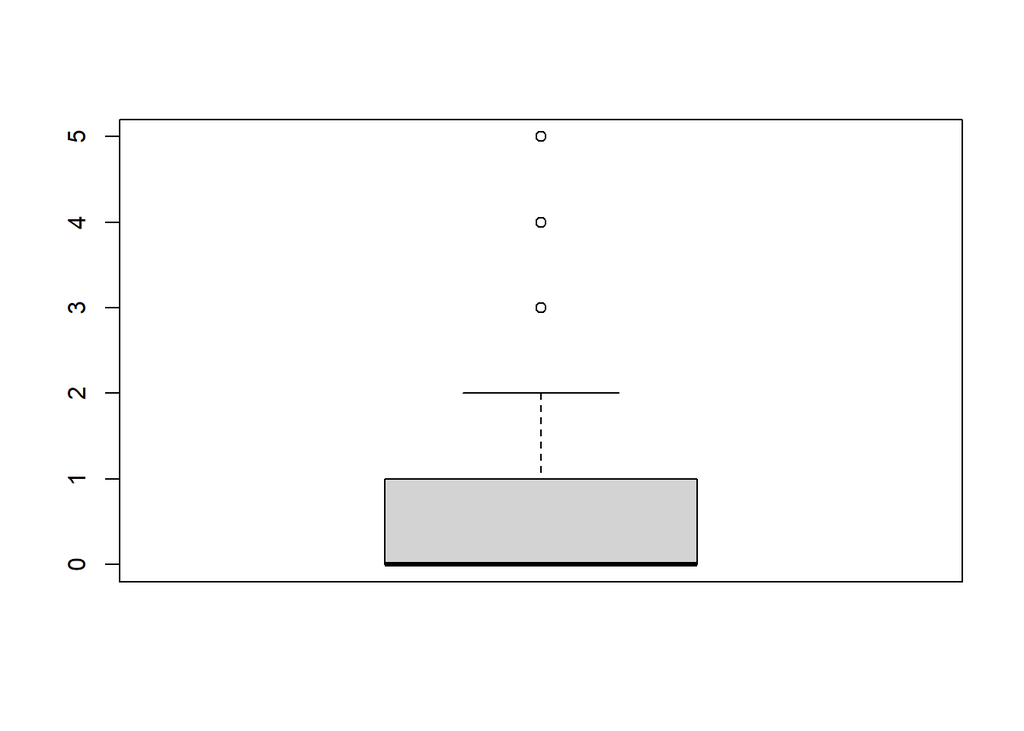

```r
#Analitzant els defenses
df <- filter(shooting, shooting$Pos_main=='DF' & shooting$noventas >=6)
boxplot(df$Gls)
```

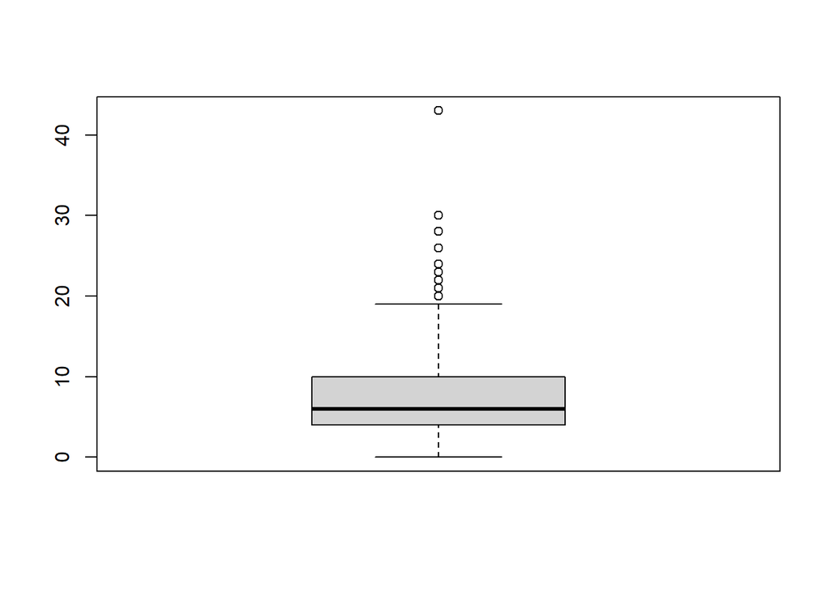

```r
boxplot(df$Sh)
```

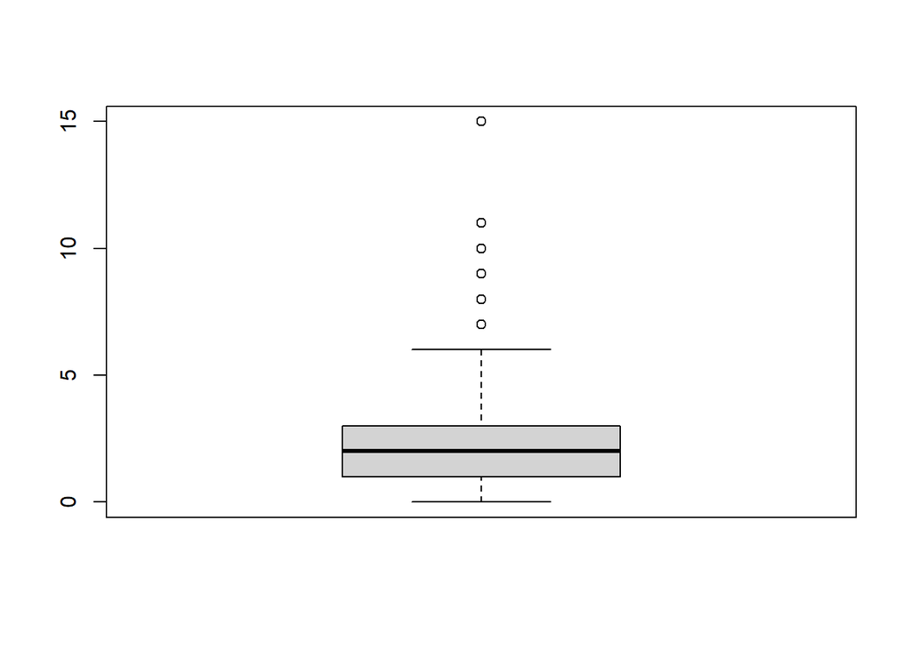

```r
boxplot(df$SoT)
```

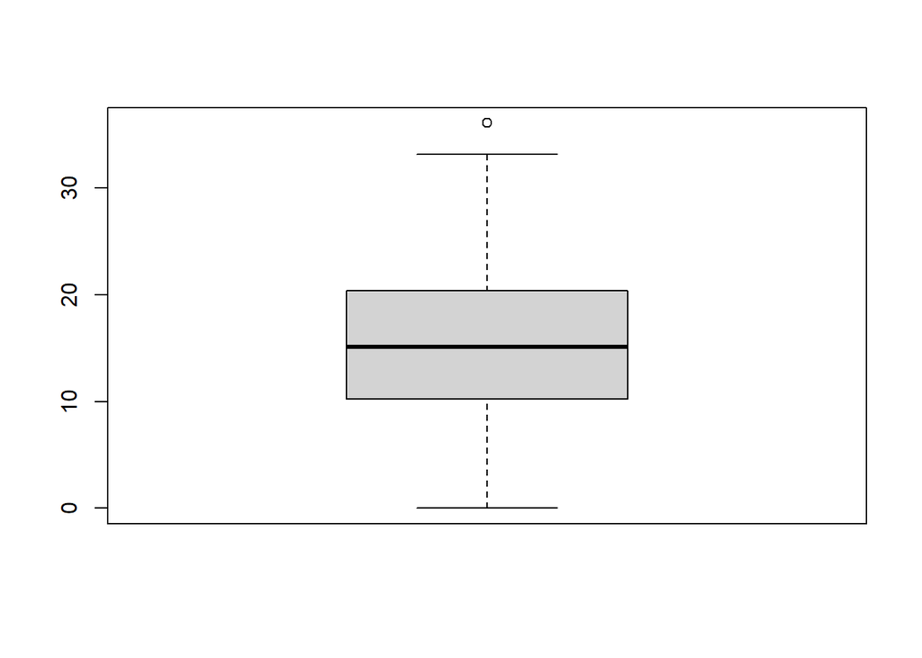

```r
boxplot(df$Dist)
```

```r
boxplot(df$FK)
```

[output not shown]

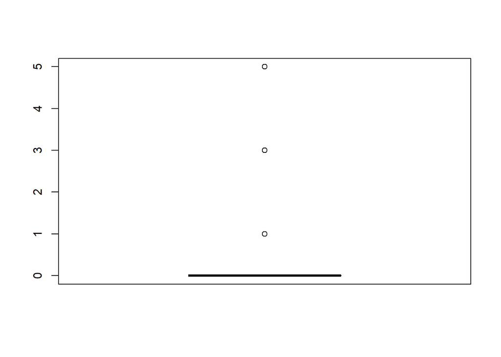

```r
boxplot(df$PK)
```

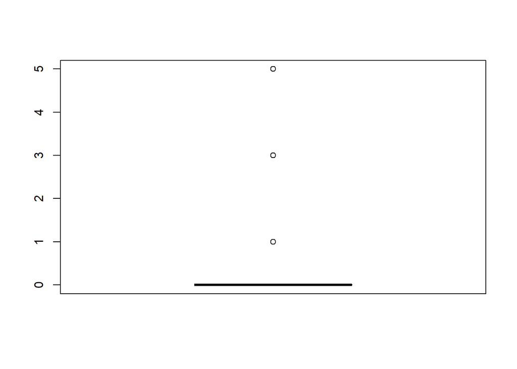

```r
boxplot(df$PKatt)
```

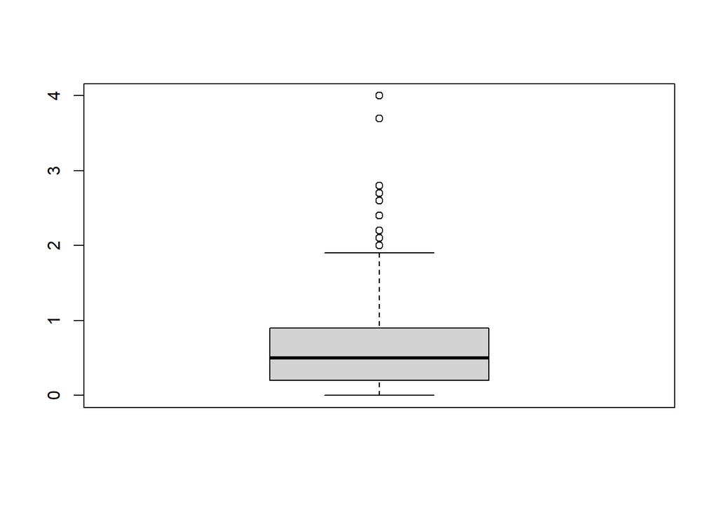

```r
boxplot(df$xG)
```